# Group_assignment

Vitalii Zhukov

3/6/2019

## Fig 2b Fractions of collaborations that are cross-disciplinary.

All data transformations are available at the code section (button at the right side of the page ->).

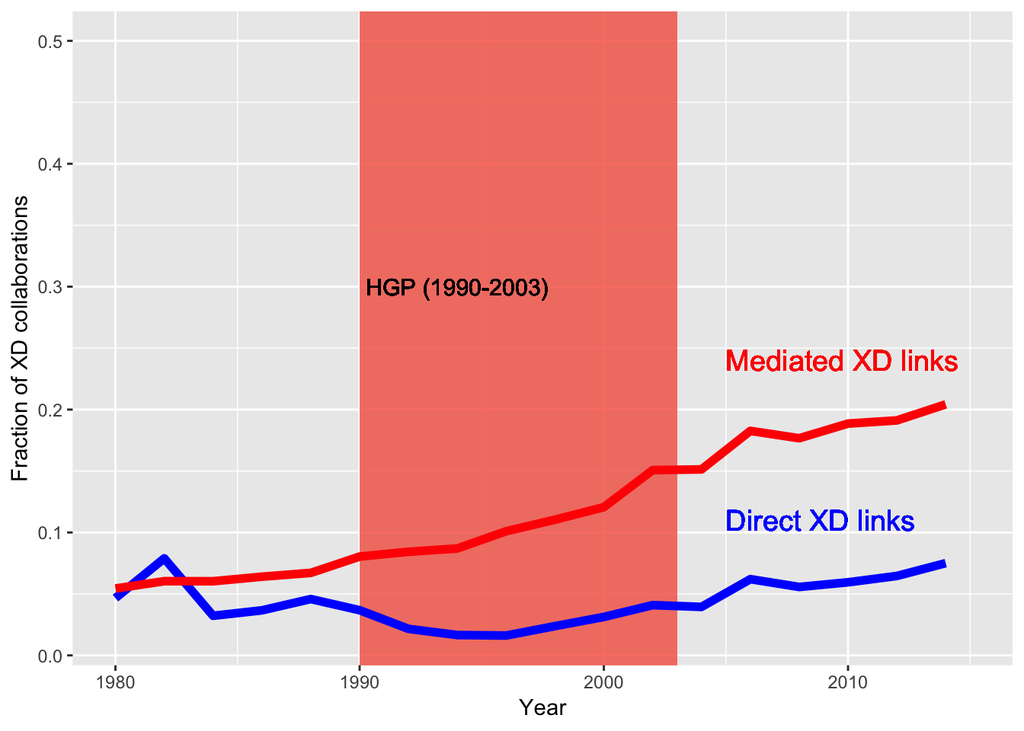

```r
library(stringr)
library(ggplot2)
library(tidyr)
library(dplyr)
library(gtools)

path <- "/Users/apple/UH-CPL/XD_Human_genom/Data_OSF" ## Path to data

## Uploading data

## Merged Google Scholar and U.S. Funding data
data1 <- read.csv(paste(path,"/Faculty_GoogleScholar_Funding_Data_N4190.csv", sep=''),
                  header = TRUE)

data4 <- read.csv(paste(path,"/GoogleScholar_paper_stats.csv", sep=''),
                  header = F)

colnames(data4)<-c("google_id", "year", "citations", "coathor_codes")
# Count total number of coathors
data4 <- cbind(data4,apply(data4["coathor_codes"],1,function(x){length(strsplit(x,',')[[1]])}))
colnames(data4)<-c("google_id", "year", "citations", "coathor_codes","coathors")

## Comment:
## total number of faculty collaborators KTotal
## find among them how many come from the opposite department and take their ratio

# Data description:
# coauthor_codes: [string] Indicates the number of coauthors and types of coauthors belonging to the publication.
# Numbers indicate “pollinator” coauthors (individuals who do not belong to the group of 4,190   set). These
# pollinators are coded as 0,1, or 2, whereas are coded according to their google_id. For example, the first
# publication line is: "1,1,1,--nVNvIAAAAJ", indicating that this publication has 4 coauthors, and only one is a
# faculty member (  ), which in this case corresponds to the google_id corresponding to the Google Schoar profile
# researcher. Pollinator codes correspond to their disciplinary type determined by the union of that particular
# individual’s set of coauthors: 0 = pollinator j only appeared in our dataset with other BIO ; 1 = pollinator j only
# appeared with other CS ; and 2 corresponds to a mixture of CS and BIO   - i.e. coauthor j is a cross-pollinator.

# 0 - BIO
# 1 - CS
# 2 - XD - pollinators (red line)
# code - direct link (blue line)

# Counting direct, mediated
data4$XD_mediators <- str_count(data4$coathor_codes, "2,|,2")

data4$direct <- data4$coathors - (str_count(data4$coathor_codes, "0,|,0|1,|,1|2,|,2")) - 1

data4$author_dept <- left_join(data4, data1, by = c("google_id"))["dept"]
data4$raw_direct_ids <- gsub("0,|,0|1,|,1|2,|,2", "", data4$coathor_codes)

data4$direct_depts <- 0

# Now lets get all direct coathors depts.
# This will take time, as O(n) for this task will be n*m*(1-150), where n-size of data4, m-size of data1, (1-150) amount of coathors.

# #for (row in 1:nrow(data4)) {
#      data4$direct_depts[row] <- paste(apply(filter(data1,
#                                                    google_id %in%
#                                                        strsplit(data4$raw_direct_ids[row],',')[[1]])["dept"],
#                                             1,
#                                             paste,
#                                             collapse=""),
#                                       collapse = ",")
#      }
# # # ET~ 32 minutes [i7-5257U @3.1 Ghz]
# #
# # # Count XD direct connections for each node
# # data4$dir_XD_p <- ifelse(data4$author_dept =="BIO",
# #                           str_count(data4$direct_depts, pattern = "CS"),
# #                           str_count(data4$direct_depts, pattern = "BIO"))
#
# # Polinators XD (leafs)
# data4$XD_polinators <- as.numeric(ifelse(data4$author_dept =="BIO",
#                           str_count(data4$coathor_codes, pattern = "1"),
#                           str_count(data4$coathor_codes, pattern = "0")))
# # Direct XD (Fi)
# data4$XD_direct <- as.numeric(ifelse(data4$author_dept =="BIO",
#                                          str_count(data4$direct_depts, pattern = "CS"),
#                                          str_count(data4$direct_depts, pattern = "BIO")))
# # Sum of direct = poli XD
# data4$XD_dir_poli <- data4$XD_polinators + data4$XD_direct
#
# # Amunt of poli links
# data4$polinators <-  data4$coathors - data4$direct
#
# # Group by year and get summary:
# data4 %>% group_by(year) %>% summarise (Total_authors = sum(coathors), # Total amount of link (TOTAL)
#                                         Total_direct = sum(direct), # Link id -to- id (Direct) (DIRECT)
#                                         Total_XD_dir_poli = sum(XD_dir_poli), # Direct (id-id) + Direct(id-num) (TOTAL XD, id, num)
#                                         Total_XD_direct = sum(XD_direct), # Direct (id-id) (TOTAL XD, id)
#                                         Total_XD_poli = sum(XD_polinators), # Id -to- 0/1 (-)
#                                         Total_poli = sum(polinators), #Id -to- 0/1/2 (POLINATORS)
#                                         Total_XD_mediators = sum(XD_mediators), # mediated (id -to- 2) (MEDIATED POLI)
#                                         Total_records = n()) %>% as.data.frame() -> data6
#
# # Dumping data, in order not to run this expensive loop every time
# write.csv(data6, file = paste(path,"/GoogleScholar_paper_stats_summary2.csv", sep=""))

# Reading dumped data
data6 <- read.csv(paste(path,"/GoogleScholar_paper_stats_summary2.csv", sep=""))

# Grouping by each 2 years (odd vs even). data6 -> data8
data6$calc_value <- data6$Total_XD_direct/data6$Total_direct
data7<-data6[odd(data6$year),]
data8<-data6[even(data6$year),]
data8$Total_authors <- (data7$Total_authors+data8$Total_authors)/2
data8$Total_direct <- (data7$Total_direct+data8$Total_direct)/2
data8$Total_XD_dir_poli <- (data7$Total_XD_dir_poli+data8$Total_XD_dir_poli)/2
data8$Total_XD_poli <- (data7$Total_XD_poli+data8$Total_XD_poli)/2
data8$Total_poli <- (data7$Total_poli+data8$Total_poli)/2
data8$Total_XD_mediators <- (data7$Total_XD_mediators+data8$Total_XD_mediators)/2
data8$Total_records <- (data7$Total_records+data8$Total_records)/2
data8$calc_value <- (data7$calc_value+data8$calc_value)/2
remove(data7)

# new plot (Mohammed suggestions)
ggplot(data=data8) +
    geom_rect(aes(xmin = 1990, xmax = 2003, ymin = -Inf, ymax = Inf, fill = "pink"), alpha = 0.1) +
    geom_line(aes(x=year, y=calc_value), color = "blue", size=2) +
    geom_line(aes(x=year, y=Total_XD_mediators/Total_poli), color = "red", size=2) +
    xlim(1980, 2015) +
    #scale_x_continuous(breaks=seq(1980,2015,by=2), limits=c(1980,2015)) +
    xlab("Year") +
    ylab("Fraction of XD collaborations") +
    theme(legend.position="none") +
    geom_text(aes(2005,0.24,label = 'Mediated XD links'), color = "red", hjust = 0, size = 5) +
    geom_text(aes(2005,0.11,label = 'Direct XD links'), color = "blue", hjust = 0, size = 5) +
    geom_text(aes(1990,0.3,label = ' HGP (1990-2003)'), color = "black", hjust = 0, size = 4)
```

**Conclusions:** We tried to quantify emergence and centrality of cross-disciplinary scholars in the network during and after HGP. We can notice mark growth during and in the wake of HGP which is greatly illustrates common trend of cross-disciplinarity growth.

## Fig 3 Descriptive statistics for the career data set

All data transformations are available at the code section (button at the right side of the page ->).

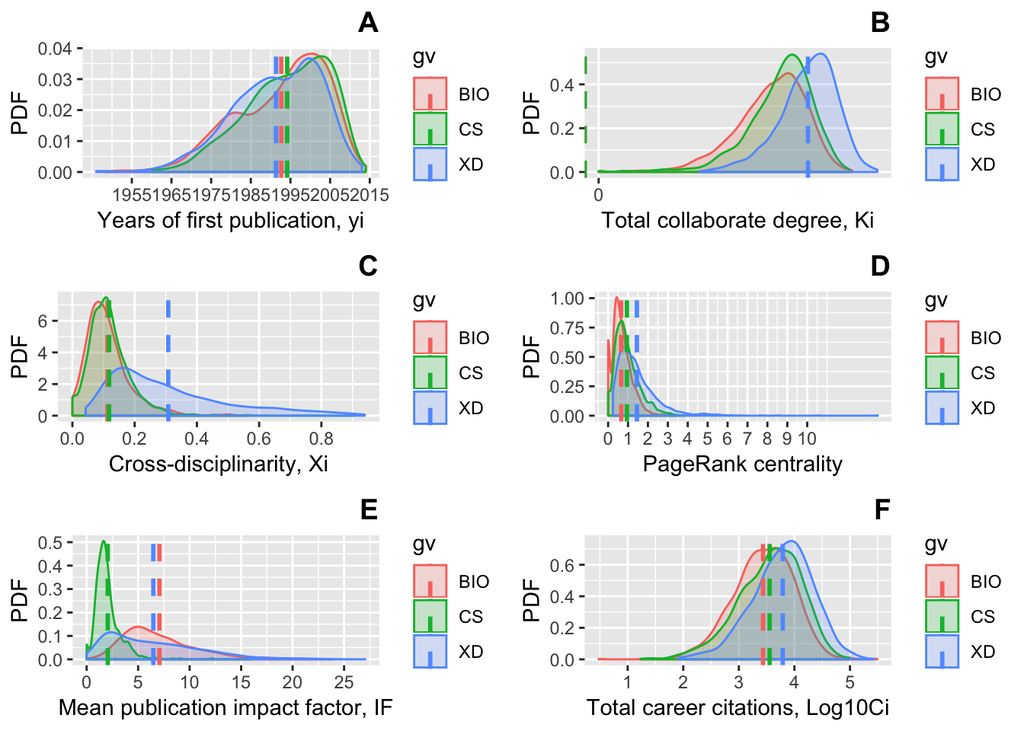

```r
## Paper "Cross-disciplinary evolution of the genomics revolution"
## Fig 3
## Research reproduced by: Vitalii Z.
## State: Issues with medians, D figure and

## Loading libraries, defining variables
library(ggplot2)
library(plyr)
library(data.table)
library(plotly)
library(gridExtra)
path <- "/Users/apple/UH-CPL/XD_Human_genom/Data_OSF" ## Path to data

## Uploading data
## Merged Google Scholar and U.S. Funding data
data1 <- read.csv(paste(path,"/Faculty_GoogleScholar_Funding_Data_N4190.csv", sep=''),
                  header = TRUE)

## Defining function for building typical PDF graphs
PDF_and_median_scaled <- function(dv, xv, ## data variable, x-axis variable
                                  gv, XscaleMin, ## group variable
                                  XscaleMax, Xstep, Xlab, GGtitle) {

    mu <- aggregate(xv,list(gv),mean)

    pv <- ggplot(data=dv, aes(x=xv, y=..density.., colour=gv, fill=gv)) +
        geom_density(alpha=0.2, adjust=1, trim=T) +
        geom_vline(data=mu, aes(xintercept=x, colour=Group.1),
                   linetype="dashed", size=1) +
        scale_x_continuous(breaks = seq(XscaleMin, XscaleMax, Xstep)) +
        xlab(Xlab) +
        ylab('PDF') +
        ggtitle(GGtitle) +
        theme(plot.title=element_text(hjust = 1, size = 14, face = "bold"))
    return(pv)
}

par(mfrow=c(2,3))
# Change the name of axis, everything else is correct
p1 <- PDF_and_median_scaled(data1,data1$min_year,data1$XDIndicator,
                           1955,2020,10, Xlab='Years of first publication, yi', GGtitle='A')

#B PDF for total collaboration degree
p2 <- PDF_and_median_scaled(data1,log(data1$KTotal),data1$XDIndicator,
                           0,2000,500, Xlab='Total collaborate degree, Ki', GGtitle='B')

#C PDF for Cross-disciplinarity
p3 <- PDF_and_median_scaled(data1,data1$Chi,data1$XDIndicator,
                           0,1,0.2, Xlab='Cross-disciplinarity, Xi', GGtitle='C')

#D PDF for Page rank centrality
p4 <- PDF_and_median_scaled(data1,data1$PRCentrality*4190,data1$XDIndicator,
                           0,10,1, Xlab='PageRank centrality', GGtitle='D')

#E PDF for mean publication impact factor
p5 <- PDF_and_median_scaled(data1,data1$mean_of_IF,data1$XDIndicator,
                           0,25,5, Xlab='Mean publication impact factor, IF', GGtitle='E')

#PDF Total career citations log10
p6 <- PDF_and_median_scaled(data1,log10(data1$t_pubs_citations),data1$XDIndicator,
                           0,6,1, Xlab='Total career citations, Log10Ci', GGtitle='F')
grid.arrange(p1,p2,p3,p4,p5,p6,ncol=2,nrow=3)
```

**Comments:**

1. Probability distribution of the year of first publication by Fi.
2. Probability distribution of Ki, the total number of collaborators for a given Fi.
3. Probability distribution of Xi, the fraction of the collaborators of Fi who are cross-disciplinary.
4. Probability distribution of Fi, the PageRank centrality of Fi;
5. Probability distribution of the mean impact factor of the publication record of Fi.
6. Probability distribution of the total citations log10 Ci of Fi.

**Conclusions:**

- Fig3A shows that typical Fi either in BIO or CS started his career in 1990s. HGP started in 1990 so this are ideal ideal groups for study.
- Fig3B demonstrates that we have significantly higher cross-collaboration degree in XD group, comparing to BIO, CS.
- Fig3C shows that the XD group has a significantly higher degree of cross-disciplinarity than CS and BIO groups. Chi represents fraction of her/his collaborators who are cross-disciplinary.
- Fig3D showing that the mean centrality of XD group is significanly higher than the mean centrality of BIO and CS.
- Fig3E shows that XD faculties have similiar publishing behavoiur as BIO faculties (high-impact factor journals). We calculated the mean Journal Citations Report (JCR) impact factor among the publication set of each faculties.
- Fig3F shows that XD group has higher mean citation impact (log10) comparing to XD and BIO faculties.

## Fig S1 Robustness of the F network with respect to link removal.

All data transformations are available at the code section (button at the right side of the page ->).

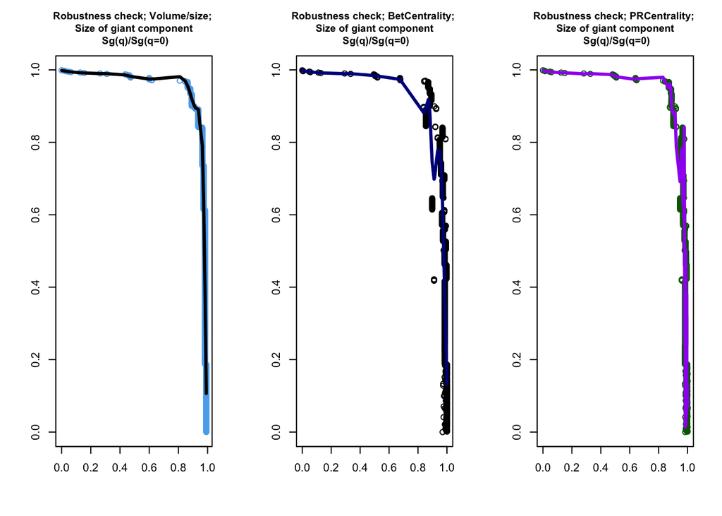

```r
## Paper "Cross-disciplinary evolution of the genomics revolution"
## Fig S1a
## Research reproduced by: Vitalii Z.
## State: In progress..

## Loading libraries, defining variables

library(splitstackshape)
library(igraph)
library(CINNA)
library(evmix)
library(NetSwan)

varY0<-1900 ## Year of network, lowest border
varY<-1990 ## Year of network, highest border

path <- "/Users/apple/UH-CPL/XD_Human_genom/Data_OSF" ## Path to data

## Uploading data

## Merged Google Scholar and U.S. Funding data
data3 <- read.csv(paste(path,"/Faculty_GoogleScholar_Funding_Data_N4190.csv", sep=''),
                  header = TRUE)

## Google Scholar — publication and citation data
data4 <- read.csv(paste(path,"/GoogleScholar_paper_stats.csv", sep=''),
                  header = F)
colnames(data4)<-c("google_id", "year", "citations", "coathor_codes")

## Transforming Data and building F-network (without polinators)

nodes <- data3
links <- data4

#summary(nodes)
#nodes[duplicated(nodes$id)]
#links[duplicated(links$id)]

colnames(nodes)[1]<-c("id") ## google_id modified to id
colnames(links)[1]<-c("from")
colnames(links)[4]<-c("to")

## Transforming links to format from:to = 1:1 and removing links to itself (loops)
links <- cSplit(links, "to", ",", "long")[to!=""]
links <- links[,c(1,4,2,3)]
links <- subset(links,! to %in% c(1,2,0) & ! as.character(from) == as.character(to))

links <- subset(links, (year <= varY) & (year >= varY0)) ## Limiting year by variable
links <- subset(links, from %in% nodes$id) ##
links <- subset(links, to %in% nodes$id)

## Validation: unique(links$from) %in% unique(nodes$id) && unique(links$to) %in% unique(nodes$id)
colnames(links)[1]<-c("Source")
colnames(links)[2]<-c("Target")
write.csv(links, file = "links.csv", row.names=F)
write.csv(nodes, file = "nodes.csv", row.names=F)

net <- graph.data.frame(links, nodes, directed=F) ## Defining network
## VERTICES

i<-1 #loop iterations
result<-c() #var to store the absolute size of current giantic subnetwork
result_B <- c()
result_PR <- c()
while (length(V(net))!=0) {
    g_comp <- giant_component_extract(net)
    result[i] <- length(V(g_comp[[1]])) #store their size and number
    result_B[i] <- sum(V(g_comp[[1]])$BetCentrality)
    result_PR[i] <- sum(V(g_comp[[1]])$PRCentrality)
    net <- delete.vertices(net, V(net)[V(g_comp[[1]])]) #substrack vetices from orig network
    i<-i+1
}

par(mfrow=c(1,3))

x <- 1-result/max(result)
y <- 1-(which(result %in% result)/length(result))
smoothingSpline = smooth.spline(x, y, spar=0.4)

plot(x, y, xlab="", ylab="",
     main="Robustness check; Volume/size; \n Size of giant component \n Sg(q)/Sg(q=0)",
     cex=1, col="steelblue2", cex.main=0.9)
lines(smoothingSpline, col="black", lwd=3)

x <- 1-result_B/max(result_B)
y <- 1-(which(result_B %in% result_B)/length(result_B))
smoothingSpline = smooth.spline(x, y, spar=1.5)
plot(x, y, xlab="", ylab="",
     main="Robustness check; BetCentrality; \n Size of giant component \n Sg(q)/Sg(q=0)",
     cex=1, col="black", cex.main=0.9)
lines(smoothingSpline,
      col="dark blue", lwd=3)

x<-1-result_PR/max(result_PR)
y<-1-(which(result_PR %in% result_PR)/length(result_PR))
smoothingSpline = smooth.spline(x, y, spar=0.5)
plot(x, y, xlab="", ylab="",
     main="Robustness check; PRCentrality; \n Size of giant component \n Sg(q)/Sg(q=0)",
     cex=1, col="darkgreen", cex.main=0.9)
lines(smoothingSpline,
      col="purple", lwd=3)
```

**Comments:**

Robustness check of network. The ratio Sg(q)/Sg(q=o) measures the size of the largest remaining fragment Sg(q), relative to the size of the initial giant component Sg(q=0). Compared subnet volumes, BetCentrality and PRcentrality values.